# 텍스트 마이닝 중간고사

20161555-BGH

2022 5 3

### 문제1. 데이터 선정이유 구조 및 내용 설명

#### 문제 2 ~ 3번 사용 데이터셋

###### 해당 분석은 실습을 목적으로 진행된 것이며 어떠한 정치적 의미도 가지지 않습니다.

20대 대통령선거 출범식떄 윤석열과 이재명이 각자 연설한 내용입니다.

강의에서 실습에 사용하는 연설문 형식으로 같으나 제시된 문제 실습에 유효한 결과를 도출할 수 있을 것으로 판단하여 해당 데이터를 선정하였습니다.

#### 문제 4 ~ 5번 사용 데이터 셋

저번해에 강의 실습으로 만들고 깃허브에 게시한 네이버 영화 댓글 리뷰 크롤러(Naver_Movie_Reply_Crawler)를 이용하여 직접 수집하였습니다.

데이터 구조는 인덱스 번호, 평점, 리뷰내용, 작성자명, 작성일자, 공감횟수, 비공감횟수 로 구성되어있으며 갯수는 총 40개입니다.

데이터는 “로스트 시티”라는 영화의 리뷰 댓글을 가져왔으며 선정이유는 게시된 리뷰가 호나 불호에 과도하게 치우쳐져 있는 영화들의 리뷰를 사용하면 감정사전을 사용하여 분석하였을때 전부 positve하거나 negative로 판단될 경우를 피하기 위해서입니다.

### 문제2. 가장 자주 사용된 단어 추출 및 빈도 그래프 만들기

#### 코드 작성 및 분석 과정

##### 0) 데이터 전처리

```r
yun_speech =
  #파일 불러오기
  readLines("yun_speech.txt", encoding = "UTF-8") %>%
  #티블로 변환
  as_tibble() %>%
  #병합 시 구분을 위한 변수 추가
  mutate(president = "yun")

lee_speech =
  #파일 불러오기
  readLines("lee_speech.txt", encoding = "UTF-8") %>%
  #티블로 변환
  as_tibble() %>%
  #병합 시 구분을 위한 변수 추가
  mutate(president = "lee")

#두 개의 연설문을 하나로 병합
speeches = bind_rows(yun_speech, lee_speech) %>%
  select(president, value) %>%
  #한글이 아닌 문자 전부 제거 ...
  mutate(value = str_replace_all(value, pattern = "[^가-힣]",  replacement = " "),
         #... 그리고 띄어쓰기가 2개이상 연속된 문자열을 하나로 압축
         value = str_squish(value))

#전처리 결과 확인
speeches
```

```
## # A tibble: 316 x 2
##    president value
##    <chr>     <chr>
##  1 yun       "존경하는 국민 여러분"
##  2 yun       "사랑하는 당원 동지 여러분"
##  3 yun       "저는 오늘 무거운 마음으로 이 자리에 섰습니다"
##  4 yun       ""
##  5 yun       "코로나 중환자가 병실이 없어"
##  6 yun       "온 가족이 고통받고 있습니다"
##  7 yun       ""
##  8 yun       "민주당 정부는"
##  9 yun       "코로나 중환자 병실을 늘리는데 써야 할 돈을"
## 10 yun       "오로지 표를 더 얻기 위해"
## # ... with 306 more rows
```

##### 1) 가장 자주 사용된 단어 추출

```r
#출범식 연설문 단어 추출
(speeches_freq = speeches %>%
  #전처리한 데이터를 형태소 분석기로 토큰화
  unnest_tokens(input = value, output = word, token = extractNoun) %>%
  #동일 단어 갯수를 세고 그 수를 기준으로 내림차순 정렬. 단, president 변수를 유지한다.
  count(president, word, sort = T) %>%
  #한 글자 이하인 모든 단어 제거
  filter(str_count(word) > 1))
```

```
## # A tibble: 663 x 3
##    president word       n
##    <chr>     <chr>  <int>
##  1 lee       국민      34
##  2 lee       우리      24
##  3 yun       우리      17
##  4 yun       국민      15
##  5 lee       기회      14
##  6 lee       이재      14
##  7 lee       정부      14
##  8 lee       대한      12
##  9 lee       민국      12
## 10 lee       여러분    11
## # ... with 653 more rows
```

##### 2) 빈도 그래프 만들기

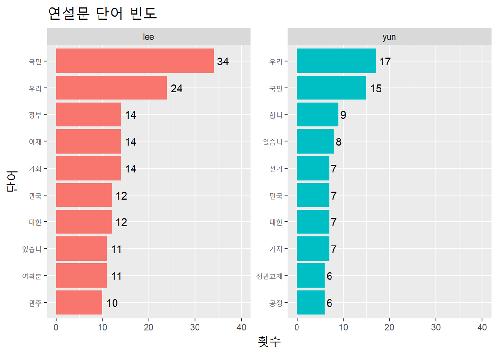

```r
top10_president_keywrod = speeches_freq %>%
  group_by(president) %>%
  slice_max(n, n=10, with_ties = F)

ggplot(top10_president_keywrod,                 #그래프에 사용할 데이터 지정
       #x축은 reorder_within(축, 정렬기준, 나누는 기준)으로 임의 기준별 정렬
       aes(x = reorder_within(word, n, president),
           #y축 기준 변수 지정
           y = n, fill = president)) +
  #막대 그래프를 그림, 범례는 표시하지 않음
  geom_col(show.legend = F) +
  #가로 => 세로 변형
  coord_flip() +
  #scales = 'free_y' 추가로 각 기준(president)별로 표 x축을 완전히 나눔
  facet_wrap(~president, scales = "free_y") +
  #그래프에 생성되는 불필요한(__yun과 같은) 항목이름 제거
  scale_x_reordered() +
  #막대바 끝 숫자 위치 오프셋
  geom_text(aes(label = n), hjust = -0.3) +
  #y축 최대값 설정
  ylim(0, 40) +
  #제목, X&Y축 제목
  labs(title = "연설문 단어 빈도", x = "단어", y = "횟수") +
  #글자 크기 변경
  theme(title = element_text(size =15))
```

### 문제3. 오즈비 또는 TF-IDF 활용하여 분석하기

#### 코드 및 분석 과정

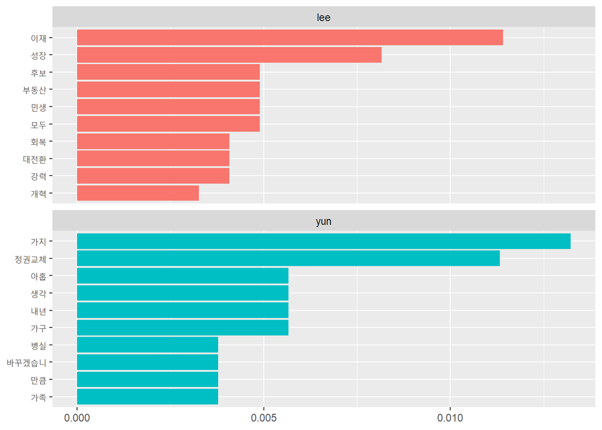

```r
#TF-IDF를 활용하여 연설문 분석
speeches_tf_idf = speeches_freq %>%
  bind_tf_idf(term = word, document = president, n = n) %>%
  group_by(president) %>%
  slice_max(tf_idf, n = 10, with_ties = F)
speeches_tf_idf$president = factor(speeches_tf_idf$president, levels = c("lee", "yun"))

#분석을 위해 TF-IDF 수치로 그래프 그리기
ggplot(speeches_tf_idf,                                 #그래프 사용 데이터 지정
       # x축은 tf_idf수치를 기준으로 word를 재정렬하고 president로 묶는다.
       aes(x = reorder_within(word, tf_idf, president),
           # y축은 tf_idf 수치로 데이터 막대를 그린다.
           y = tf_idf,
           # 대통령(president) 기준으로 색지정
           fill = president)) +
  #막대 그래프를 그리며 범례(legend)를 표시 하지 않음
  geom_col(show.legend = F) +
  #세로 막대 그래프로 변경
  coord_flip() +
  # president별로 막대그래프를 따로그린다.
  facet_wrap(~president,
             # x축만 각 막대그래프에 독립적으로 조절한다. (y축의 최소/대값은 통일된다.)
             scales = "free_y",
             # 2열로 배치한다.
             nrow = 2) +
  #x축에 ___yun과 같이 불필요한 어미를 제거한다.
  scale_x_reordered() +
  #x축과 y축의 라벨을 제거한다.
  labs(x = NULL, y = NULL)
```

#### 결과 해석

TF-IDF는 흔하지 않고 한 텍스트에서 자주 사용되면 높은 값을 나타낸다.

위의 결과에서 단어가 “가지”, “이재” 같은 의미 없는 단어를 제외했을 때

이재명의 연설문에서는 “성장”을 강조하며 그 다음으로 “부동산, 민생, 회복”순서로 특징성을 보이며

그래프에 나온 단어들을 조합해보면 “성장을 위해 부동산과 민생 회복 관련으로 대전환(또는 개혁)을 시도할 것”으로 보인다.

윤석열의 연설문에서는 “정권교체”을 강조하며 그 다음으로 “생각, 내년, 가구”순으로 특징성을 보이며

그래프의 결과에서 “정권교체”의 TF-IDF 수치가 두 연설문의 단어 중 제일 높아 “정권교체를 하겠다”는 의지가 큼을 볼 수 있다.

### 문제4. 감정사전을 적용하여, 텍스트의 감정 경향을 분석하기

#### 코드 작성 및 분석 과정

##### 0) 크롤링한 데이터에서 리뷰내용만 가져오고 전처리하기

```r
#감정 사전을 불러옴
dic = read_csv("knu_sentiment_lexicon.csv")
#영화 댓글 리뷰 데이터에서
replys = read_excel("2022-05-03-01-45-22-로스트 시티.xls",
                    #리뷰내용(3열)만 가져오며
                    range = cell_cols(3),
                    #열의 이름은 "reply"로 설정하고 머릿글 행(1번째) 제거
                    col_names = "reply")[-1,] %>%
  #문장을 띄어쓰기 기준(words)으로 토큰화하고 원문을 유지(drop = F)한다.
  unnest_tokens(input = reply, output = word, token = "words", drop = F)
```

##### 1) 감정사전 적용

```r
#단어 감정 점수를 부여하는 과정
sen_score = replys %>%
  #우측에 감정 사전을 단어 기준(by = word)으로 티블 병합
  left_join(dic, by = "word") %>%
  #감정 사전에서 누락된 단어들로 인한 NA 점수는 0으로 처리
  mutate(polarity = ifelse(is.na(polarity), 0, polarity))

#감정 점수가 부여된 단어를 문장단위로 합치는 과정
sen_score_sum = sen_score %>%
  #문장을 기준으로
  group_by(reply) %>%
  #감정 점수를 전부 합친다.
  summarise(score = sum(polarity)) %>%
  #문장에 인덱스 번호를 부여
  mutate(id = row_number())

#점수가 부여된(0점이 아닌) 단어[표4-1]
sen_score %>% filter(polarity != 0)
```

```
## # A tibble: 23 x 3
##    reply                                                          word  polarity
##    <chr>                                                          <chr>    <dbl>
##  1 이 영화의 진미는 영화를 다 보고 나서 웃긴다는 것이다. 다시 생~ 비싼        -2
##  2 이것은 액션인가 로맨스인가. 지금까지 이런 영화는 많았다~. 비~  비싼        -2
##  3 작품성과 별개로 S급 배우들의 덜떨어진 모습을 보는 건 역시 재~  재미~        2
##  4 시간순삭! 두 배우의 케미도 보는 재미에 시간 가는줄 몰랐네해리~ 하드~        2
##  5 열일하는 배우와 자막이 안쓰럽다                                안쓰~       -1
##  6 그냥 계속 넘 웃겼어요 황당하면서 계속 유쾌하게 봤네요 아무생~  유쾌~        2
##  7 그냥 계속 넘 웃겼어요 황당하면서 계속 유쾌하게 봤네요 아무생~  좋은         2
##  8 가볍게 웃으러 보는 용도의 영화. 커다란 스케일을 기대했다면 실~ 가볍~       -1
##  9 브래드 피트의 존재감이 돋보였던 영화..좋은 배우들을 모아둔거 ~ 좋은         2
## 10 이렇게 재미 없는 영화를 왜 수입하는지...                       재미         2
## # ... with 13 more rows
```

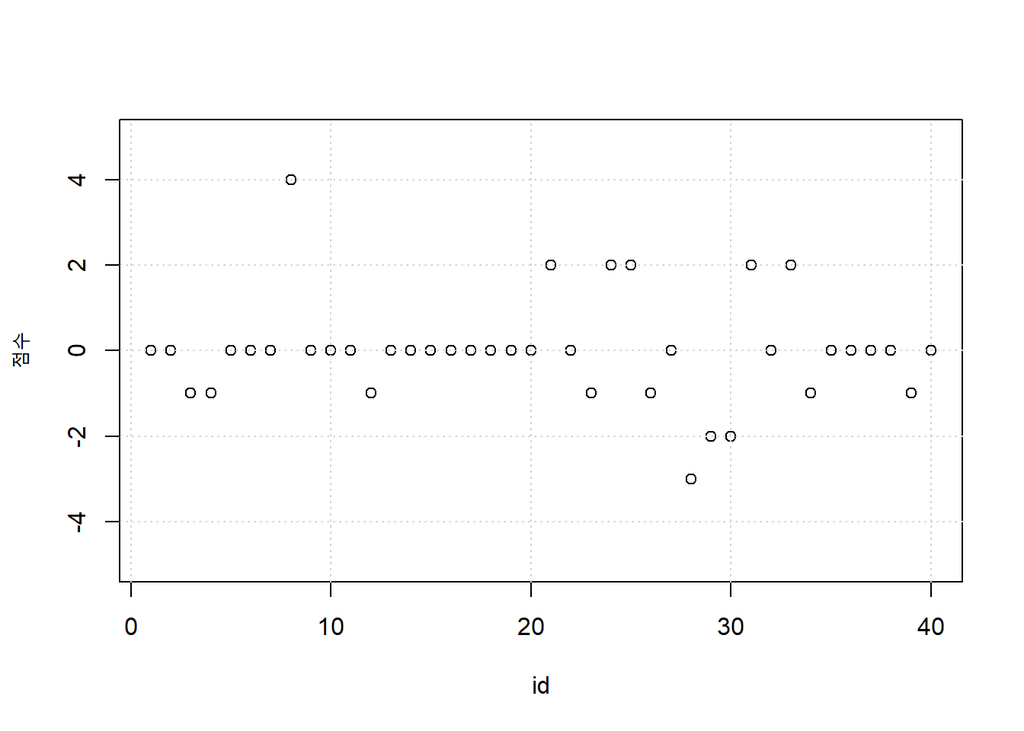

```
## integer(0)
```

```r
#산점도를 이용하여 모든 댓글의 감정점수 분포를 그래프로 확인[그래프4-1]
plot(x = sen_score_sum$id, y = sen_score_sum$score, xlab = "id", ylab = "점수", ylim = c(-5, 5)) +
  grid()
```

#### 분석결과

표4-1을 확인해보면 점수가 매겨진(0점이 아닌) 단어는 23개로 확인되었으며 확인된 단어 393개에 비해 극히 적은 갯수를 보인다.

### 문제5. 감정사전 수정하여 적용하고, 수정전과 비교분석하기

#### 코드 작성 및 분석 과정

##### 1) 감정사전 수정하기

```r
# 점수가 2인 새로운 단어 목록
p2_words = tibble(
  word = c("강렬했고", "개꿀잼으로", "만족합니다", "귀여웠고", "멋있음", "멋있어",
           "반갑고", "빛난다", "유쾌하게", "잼나네요", "재밌었어요", "좋았음",
           "ㅋㅋㅋㅋ", "하드캐리", "하드캐리하고"),
  polarity = 2)

# 점수가 1인 새로운 단어 목록
p1_words = tibble(
  word = c("가볍게", "신선함", "아기자기한", "웃겼다", "웃겼어요", "웃긴다는", "ㅋㅋ"),
  polarity = 1)

# 점수가 -1인 새로운 단어 목록
m1_words = tibble(
  word = c("당황스러움", "반감", "아쉬웠습니다","아쉬웠지만", "아쉽", "황당하면서"),
  polarity = -1)

# 점수가 -2인 새로운 단어 목록
m2_words = tibble(
  word = c("노잼", "드럽게", "실망할지도", "아님", "않고", "않은", "어정쩡한", "없고",
           "없는", "없는데", "재능낭비", "재미없음", "정색하시다가", "진부하게",
           "터무니", "헛웃음이"),
  polarity = -2)


#단어를 추가하거나 감정 점수를 수정하여 수정된 감정 사전 생성
cst_dic = dic %>%
  #감정 점수 수정
  mutate(polarity = ifelse(word %in% c("재미"), 0, polarity)) %>%
  #새로운 단어 추가
  bind_rows(p2_words, p1_words, m1_words, m2_words)
```

##### 2) 수정된 감정사전 적용

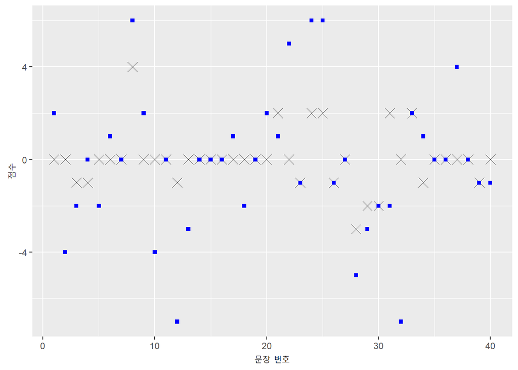

```r
#단어 감정 점수를 부여하는 과정
cst_sen_score = replys %>%
  #우측에 감정 사전을 단어 기준(by = word)으로 티블 병합
  left_join(cst_dic, by = "word") %>%
  #감정 사전에서 누락된 단어들로 인한 NA 점수는 0으로 처리
  mutate(polarity = ifelse(is.na(polarity), 0, polarity))

#감정 점수가 부여된 단어를 문장단위로 합치는 과정
cst_sen_score_sum = cst_sen_score %>%
  #문장을 기준으로
  group_by(reply) %>%
  #감정 점수를 전부 합친다.
  summarise(score = sum(polarity)) %>%
  #문장에 인덱스 번호를 부여
  mutate(id = row_number())

#변경전과 후의 점수 변화를 한눈에 보기위해 두 데이터를 겹쳐 그림
ggplot() +
  #감정사전 변경 전의 데이터를 그림
  geom_point(data = sen_score_sum,  #감정 점수 변경 전의 데이터
             #x축은 문장 번호, y축은 감정 점수
             mapping = aes(x = id, y = score),
             #모양 설정
             shape = 4,
             #점의 크기, 투명도 설정
             size = 4, alpha = 0.8) +
  #감정사전 변경 후의 데이터를 그림
  geom_point(data = cst_sen_score_sum, #감정 점수 변경 후의 데이터
             #x축은 문장 번호, y축은 감정 점수
             mapping = aes(x = id, y = score),
             #모양 설정 : 색칠된 네모
             shape = 15,
             #색갈 지정 : 파랑
             color = "blue") +
  #x축, y축의 이름 변경
  labs(x = "문장 번호", y = "점수")
```

#### 분석결과

위의 표에서 X 표시는 감정사전을 그냥 적용한 데이터이고 파란색 네모는 감정사전을 수정 후 적용한 데이터이다.

눈으로 보기에도 알 수 있듯이 두 데이터가 겹치는 부분이 많지 않으며 어떠한 것은 점수변동이 크게 일어난 데이터도 있다.

이전 데이터에서는 대부분이 중립적으로 분석되어 알 수 없었으나 수정된 데이터에서는 영화 전체 평점 10점 중 5점대를 보여준 만큼 매우 다양한 경향을 보이고있다.

### 추가점수문제. github로 버전관리 진행하고, 그 과정을 증비하기